# Medellin neighborhood clustering given accidents analytics

9

2018

9.083333

1.8809250

16

13

10

66

0

4

71

1

37

1

1

13

12

10

69

0

3

2014

10.416667

2.5030285

10

7

10

93

0

5

69

2

54

2

0

0

17

4

102

0

0

parque juan pablo ii

2015

9.083333

2.6784776

11

9

10

75

0

4

74

3

32

3

0

0

13

3

90

0

0

parque juan pablo ii

2016

13.750000

4.3301270

28

4

14

109

0

10

113

0

52

0

0

1

22

4

138

0

0

parque juan pablo ii

2017

13.000000

3.0748245

15

6

12

114

0

9

78

1

77

1

1

11

29

25

89

0

0

parque juan pablo ii

2018

12.500000

4.2958754

12

11

5

115

0

7

84

2

64

1

0

17

17

18

97

0

0

parque norte

2014

7.833333

3.4067669

11

8

3

71

0

1

45

0

49

0

1

0

11

1

79

0

2

parque norte

2015

8.083333

2.0207259

12

9

4

69

0

3

53

1

43

1

0

0

7

0

86

0

3

parque norte

2016

8.416667

2.9987371

7

9

11

70

0

4

61

0

40

0

0

0

16

1

83

0

1

parque norte

2017

3.727273

2.4531983

5

3

5

26

0

2

25

0

16

0

0

0

6

7

28

0

0

parque norte

2018

3.300000

1.8287822

2

5

2

23

0

1

16

0

17

0

0

0

6

3

24

0

0

patio bonito

2014

15.666667

6.7733882

16

9

13

146

0

4

78

0

110

0

1

0

25

5

156

0

1

patio bonito

2015

14.750000

5.7227616

11

4

6

154

0

2

68

1

108

1

0

0

26

3

147

0

0

patio bonito

2016

14.333333

4.7161875

11

5

7

141

0

8

69

1

102

1

0

0

18

3

150

0

0

patio bonito

2017

18.166667

3.5376760

16

6

8

183

0

5

81

0

137

0

1

0

31

12

171

0

3

patio bonito

2018

17.083333

5.3335701

8

9

8

177

0

3

71

0

134

0

1

1

33

14

153

0

3

pedregal

2014

15.583333

5.0535016

39

32

40

71

0

5

156

0

31

0

2

0

27

7

151

0

0

pedregal

2015

14.833333

3.0100841

25

37

19

88

0

9

138

1

39

1

0

2

38

8

129

0

0

pedregal

2016

14.250000

4.2022721

24

34

31

77

0

5

137

2

32

2

0

2

35

8

124

0

0

pedregal

2017

15.000000

5.5595945

32

33

28

80

0

7

144

1

35

1

1

1

29

34

114

0

0

pedregal

2018

15.416667

4.1221868

27

34

42

77

0

5

146

3

36

2

0

4

35

57

87

0

0

pedregal alto

2014

1.000000

0.0000000

1

0

1

3

0

0

3

0

2

0

0

0

0

0

5

0

0

pedregal alto

2015

1.500000

0.8366600

1

0

2

4

0

2

7

0

2

0

0

0

0

1

8

0

0

pedregal alto

2016

2.000000

1.2247449

3

2

3

2

0

0

9

0

1

0

0

0

0

1

9

0

0

pedregal alto

2017

1.285714

0.4879500

3

0

2

3

0

1

8

0

1

0

0

0

1

2

6

0

0

pedregal alto

2018

1.300000

0.6749486

4

0

4

5

0

0

10

0

3

0

0

0

1

6

6

0

0

pedregal bajo

2014

2.750000

1.5447860

12

1

5

14

0

1

25

0

8

0

0

0

2

1

30

0

0

pedregal bajo

2015

2.454546

1.3684763

3

3

8

10

0

3

24

0

3

0

0

0

1

1

25

0

0

pedregal bajo

2016

2.181818

1.3280197

5

1

5

11

0

2

21

0

3

0

0

0

1

2

21

0

0

pedregal bajo

2017

2.000000

1.6733201

0

0

4

7

0

1

9

0

3

0

0

0

1

3

8

0

0

pedregal bajo

2018

1.000000

0.0000000

1

1

1

1

0

0

3

1

0

1

0

0

0

0

3

0

0

perpetuo socorro

2014

64.583333

8.6493125

72

29

40

612

0

22

384

2

389

2

4

19

112

15

603

0

20

perpetuo socorro

2015

67.000000

7.8624539

55

41

52

632

0

24

388

4

412

4

4

17

150

18

602

0

9

perpetuo socorro

2016

72.916667

10.6979890

96

32

54

673

0

20

402

5

468

5

2

22

145

20

665

0

16

perpetuo socorro

2017

72.583333

6.4731380

63

28

54

702

0

24

373

0

498

0

4

24

201

55

542

0

45

perpetuo socorro

2018

66.416667

10.0946280

67

30

48

629

0

23

349

3

445

1

3

22

172

61

496

0

42

picachito

2014

1.714286

0.9511897

4

4

4

0

0

0

12

0

0

0

0

0

0

0

12

0

0

picachito

2015

1.571429

0.5345225

4

3

0

4

0

0

10

0

1

0

0

0

1

0

10

0

0

picachito

2016

1.625000

1.1877349

3

3

3

3

0

1

12

0

1

0

0

0

2

3

8

0

0

picachito

2017

1.500000

0.7977240

1

5

4

4

0

4

16

0

2

0

1

0

0

4

13

0

0

picachito

2018

2.000000

1.0954451

6

0

9

6

0

1

18

0

4

0

0

0

2

11

9

0

0

picacho

2014

12.250000

3.8641711

29

25

35

57

0

1

118

0

29

0

0

0

10

7

130

0

0

picacho

2015

12.916667

2.7455198

29

18

38

63

0

7

120

0

35

0

0

0

12

6

137

0

0

picacho

2016

14.000000

3.7899388

32

42

28

61

0

5

130

0

38

0

0

0

19

12

137

0

0

picacho

2017

13.000000

5.5103209

30

24

36

61

0

5

123

1

32

1

0

0

13

34

108

0

0

picacho

2018

12.166667

3.5632807

20

21

35

68

0

2

109

0

37

0

0

0

16

57

71

0

2

piedra gorda

2017

1.000000

NA

0

0

0

1

0

0

0

0

1

0

0

0

1

0

0

0

0

piedras blancas

2014

1.272727

0.6466698

2

5

2

4

0

1

11

0

3

0

0

0

0

2

12

0

0

piedras blancas

2015

2.300000

1.3374935

1

10

3

7

0

2

21

0

2

0

0

0

0

1

22

0

0

piedras blancas

2016

1.600000

0.6992059

1

6

3

6

0

0

12

1

3

1

0

0

0

2

13

0

0

piedras blancas

2017

2.500000

1.2692955

3

12

3

6

0

1

21

0

4

0

1

0

1

9

14

0

0

piedras blancas

2018

2.333333

1.4142136

0

7

2

12

0

0

14

0

7

0

0

0

0

5

16

0

0

piedras blancas - matasano

2015

1.000000

NA

0

0

1

0

0

0

1

0

0

0

0

0

0

1

0

0

0

piedras blancas represa

2014

1.333333

0.8164966

2

1

3

1

0

1

7

0

1

0

0

0

0

0

8

0

0

piedras blancas represa

2015

1.666667

0.5773503

0

0

0

5

0

0

3

0

2

0

0

0

0

0

5

0

0

piedras blancas represa

2016

1.000000

0.0000000

0

0

2

1

0

0

2

0

1

0

1

0

1

0

1

0

0

piedras blancas represa

2017

1.000000

0.0000000

1

0

0

0

0

1

2

0

0

0

0

0

0

0

2

0

0

piedras blancas represa

2018

1.500000

0.5773503

2

0

1

2

0

1

5

0

1

0

0

0

0

1

5

0

0

playon de los comuneros

2014

5.333333

2.2696949

7

23

4

30

0

0

48

0

16

0

1

0

7

1

55

0

0

playon de los comuneros

2015

5.416667

2.4293034

6

7

12

36

0

4

47

1

17

1

0

0

7

2

55

0

0

playon de los comuneros

2016

4.500000

2.2763607

4

15

4

25

0

6

43

0

11

0

0

0

3

3

48

0

0

playon de los comuneros

2017

5.250000

2.0943647

9

8

2

43

0

1

34

0

29

0

0

0

21

8

34

0

0

playon de los comuneros

2018

6.166667

2.3677121

9

10

5

46

0

4

43

2

29

1

0

0

10

12

50

0

1

plaza de ferias

2014

2.333333

1.3026779

2

1

2

23

0

0

18

0

10

0

0

0

3

0

25

0

0

plaza de ferias

2015

2.333333

1.5811388

1

5

0

14

0

1

11

1

9

1

0

0

3

0

16

0

1

plaza de ferias

2016

3.000000

2.0449494

1

4

2

29

0

0

23

0

13

0

0

0

6

2

28

0

0

plaza de ferias

2017

2.363636

1.2060454

0

3

2

20

0

1

18

0

8

0

0

0

8

3

15

0

0

plaza de ferias

2018

2.000000

0.8660254

0

0

0

18

0

0

8

0

10

0

0

0

1

1

16

0

0

popular

2014

10.083333

3.8954130

18

35

18

48

1

1

85

1

35

1

2

0

4

1

113

0

0

popular

2015

7.916667

3.1176429

11

25

16

39

0

4

71

0

24

0

0

0

7

7

81

0

0

popular

2016

7.333333

3.0846639

9

29

6

41

0

3

60

0

28

0

0

0

5

3

80

0

0

popular

2017

6.583333

1.8809250

6

20

16

33

0

4

55

1

23

1

0

0

7

14

57

0

0

popular

2018

6.750000

2.0504988

16

18

13

32

0

2

57

0

24

0

0

0

5

30

46

0

0

potrerito

2014

1.000000

0.0000000

0

1

0

1

0

0

1

0

1

0

0

0

1

0

1

0

0

potrerito

2015

1.000000

NA

0

0

0

1

0

0

1

0

0

0

0

0

0

0

1

0

0

potrerito

2017

1.000000

NA

0

0

0

1

0

0

1

0

0

0

0

0

0

0

1

0

0

potrerito

2018

1.000000

NA

0

0

0

1

0

0

1

0

0

0

0

0

0

0

1

0

0

prado

2014

38.583333

6.0371326

42

41

36

335

0

9

252

2

209

2

0

0

116

3

342

0

0

prado

2015

36.166667

6.8600733

34

35

36

311

0

18

236

2

196

2

1

1

121

5

304

0

0

prado

2016

33.500000

6.5017480

37

36

25

284

1

19

233

2

167

2

3

0

110

9

278

0

0

prado

2017

31.666667

7.7733032

29

23

21

296

0

11

214

0

166

0

0

0

187

25

167

0

1

prado

2018

29.000000

6.1200119

25

29

25

261

0

8

212

8

128

5

2

0

176

37

128

0

0

robledo

2014

14.500000

2.9076701

29

18

23

100

0

4

107

0

67

0

0

0

25

5

143

0

1

robledo

2015

17.500000

5.1433982

35

25

27

108

0

15

143

1

66

1

1

0

28

7

172

0

1

robledo

2016

17.416667

4.9627400

42

17

36

97

0

17

160

1

48

1

0

0

15

10

182

0

1

robledo

2017

20.750000

5.9103146

53

13

41

125

0

17

174

2

73

2

0

0

39

43

164

0

1

robledo

2018

15.750000

3.8168288

26

11

41

101

0

10

134

1

54

1

0

0

25

56

106

0

1

rosales

2014

22.333333

3.1430539

19

17

21

208

0

3

135

0

133

0

1

0

56

5

203

0

3

rosales

2015

23.833333

6.6446606

21

13

16

229

0

7

148

1

137

1

0

3

78

3

199

0

2

rosales

2016

27.500000

4.3379928

20

11

30

255

0

14

180

2

148

2

1

2

76

8

239

1

1

rosales

2017

25.500000

6.4737231

31

18

16

230

0

11

174

0

132

0

1

0

120

25

156

0

4

rosales

2018

26.083333

4.2949936

18

19

15

257

0

4

160

3

150

2

0

4

107

26

170

0

4

san antonio

2014

1.400000

0.5477226

2

1

2

2

0

0

5

0

2

0

0

0

0

0

7

0

0

san antonio

2015

1.400000

0.5477226

0

1

1

4

0

1

4

0

3

0

0

0

0

0

7

0

0

san antonio

2016

1.200000

0.4472136

0

2

1

2

0

1

6

0

0

0

0

0

0

0

6

0

0

san antonio

2017

2.000000

NA

1

0

1

0

0

0

2

0

0

0

0

0

0

1

1

0

0

san antonio

2018

1.000000

NA

1

0

0

0

0

0

1

0

0

0

0

0

0

1

0

0

0

san benito

2014

58.000000

11.3458042

46

97

45

497

0

11

305

7

384

7

2

0

83

17

580

0

7

san benito

2015

72.333333

14.4243061

55

105

53

633

0

22

369

13

486

13

1

2

74

22

751

0

5

san benito

2016

60.833333

8.8094302

56

88

46

519

0

21

333

4

393

4

1

0

82

26

608

2

7

san benito

2017

47.083333

10.5525381

48

55

23

425

0

14

224

3

338

3

2

2

99

43

405

0

11

san benito

2018

48.166667

8.9932635

32

65

31

435

1

14

240

1

337

1

0

1

111

61

392

0

12

san bernardo

2014

15.166667

3.0100841

15

17

17

125

0

8

99

0

83

0

1

0

32

1

148

0

0

san bernardo

2015

15.916667

2.2343733

12

26

16

131

0

6

120

1

70

1

0

0

32

6

152

0

0

san bernardo

2016

19.916667

4.0330078

30

27

22

152

0

8

146

1

92

1

0

0

56

7

174

0

1

san bernardo

2017

17.333333

5.1049590

30

20

19

129

0

10

123

1

84

1

2

0

61

28

116

0

0

san bernardo

2018

15.750000

3.3063300

19

21

11

132

0

6

108

6

75

4

1

0

70

24

90

0

0

san diego

2014

45.666667

9.7731853

48

41

51

393

0

15

248

2

298

2

1

17

47

17

447

0

17

san diego

2015

48.666667

7.8315601

55

32

36

446

0

15

244

0

340

0

1

32

42

24

480

0

5

san diego

2016

49.833333

6.0877423

51

22

32

477

0

16

238

2

358

2

1

35

45

30

473

0

12

san diego

2017

48.916667

7.2545701

60

31

36

444

0

16

246

2

339

2

1

45

70

63

381

0

25

san diego

2018

45.250000

7.2503918

29

22

22

454

0

16

174

6

363

4

1

50

83

67

318

0

20

san german

2014

8.416667

3.6545945

12

13

7

69

0

0

50

0

51

0

2

0

12

4

83

0

0

san german

2015

9.583333

3.7284736

11

15

6

78

0

5

66

3

46

3

1

1

16

2

92

0

0

san german

2016

10.583333

2.7784343

11

14

6

92

0

4

78

0

49

0

1

0

12

6

105

0

3

san german

2017

11.083333

3.8954130

12

7

8

102

0

4

69

0

64

0

0

0

31

13

86

0

3

san german

2018

14.583333

5.5670840

14

17

12

128

0

4

92

2

81

2

1

1

32

25

112

0

2

san isidro

2014

13.166667

3.4067669

30

25

24

74

0

5

113

2

43

2

1

0

23

2

128

0

2

san isidro

2015

15.416667

3.7284736

26

31

26

97

0

5

139

1

45

1

0

0

34

5

143

0

2

san isidro

2016

19.083333

3.3967453

37

33

31

116

0

12

173

2

54

2

1

2

49

7

167

0

1

san isidro

2017

19.000000

3.5675303

37

21

25

139

0

6

157

0

71

0

0

2

69

40

115

0

2

san isidro

2018

17.333333

6.4291005

25

25

31

119

0

8

144

0

64

0

1

8

49

40

103

0

7

san javier

2017

1.000000

0.0000000

0

1

0

1

0

0

0

2

0

2

0

0

0

0

0

0

0

san javier no.1

2014

13.500000

3.0000000

25

23

23

84

0

7

119

0

43

0

0

3

24

6

128

0

1

san javier no.1

2015

11.666667

2.5346089

20

17

15

79

0

9

90

1

49

1

0

7

21

6

105

0

0

san javier no.1

2016

12.583333

2.9987371

18

20

20

84

0

9

106

2

43

2

0

9

28

2

110

0

0

san javier no.1

2017

12.750000

4.7887178

25

17

20

83

0

8

111

1

41

1

0

10

39

30

73

0

0

san javier no.1

2018

10.250000

4.4543135

12

20

13

74

0

4

84

0

39

0

0

9

42

23

49

0

0

san javier no.2

2014

5.666667

1.5569979

8

16

7

36

0

1

42

1

25

1

1

0

13

1

52

0

0

san javier no.2

2015

4.250000

1.7645499

5

11

7

28

0

0

35

0

16

0

0

1

5

2

43

0

0

san javier no.2

2016

6.250000

1.9128750

8

20

8

35

0

4

55

0

20

0

0

0

14

2

59

0

0

san javier no.2

2017

4.454546

1.7529196

8

6

4

31

0

0

30

0

19

0

0

0

15

8

26

0

0

san javier no.2

2018

4.000000

1.8586408

5

6

8

28

0

1

25

0

23

0

0

0

14

8

26

0

0

san joaquin

2014

11.000000

2.8919952

9

9

6

105

0

3

57

2

73

2

0

0

21

4

105

0

0

san joaquin

2015

11.333333

3.7979261

8

12

8

105

0

3

73

0

63

0

0

0

21

2

112

0

1

san joaquin

2016

13.416667

3.9648073

14

13

7

119

0

8

88

1

72

1

0

0

30

6

123

1

0

san joaquin

2017

8.833333

3.5118846

8

10

3

82

0

3

47

1

58

1

0

0

24

6

75

0

0

san joaquin

2018

10.750000

3.8876261

8

7

4

107

0

3

56

3

70

2

1

0

38

9

79

0

0

san jose de la montana

2017

1.000000

NA

1

0

0

0

0

0

1

0

0

0

0

0

0

1

0

0

0

san jose de la montana

2018

1.000000

NA

0

0

0

1

0

0

0

0

1

0

0

0

0

0

1

0

0

san jose la cima no. 1

2014

1.000000

0.0000000

1

2

0

1

0

1

4

0

1

0

0

0

0

1

4

0

0

san jose la cima no. 1

2015

1.571429

0.7867958

0

4

0

7

0

0

7

1

3

1

0

0

0

0

10

0

0

san jose la cima no. 1

2016

1.333333

0.5163978

2

1

2

3

0

0

8

0

0

0

0

0

0

0

8

0

0

san jose la cima no. 1

2017

1.400000

0.5477226

3

0

1

3

0

0

4

0

3

0

0

0

1

2

4

0

0

san jose la cima no. 1

2018

1.250000

0.5000000

0

4

1

0

0

0

5

0

0

0

0

0

0

2

3

0

0

san jose la cima no.2

2014

1.000000

0.0000000

4

2

2

0

0

0

8

0

0

0

1

0

0

1

6

0

0

san jose la cima no.2

2015

1.000000

0.0000000

0

1

1

1

0

1

3

0

1

0

0

0

0

0

4

0

0

san jose la cima no.2

2016

1.000000

0.0000000

1

0

1

0

0

0

2

0

0

0

0

0

0

0

2

0

0

san jose la cima no.2

2017

1.500000

0.7071068

2

0

1

0

0

0

3

0

0

0

0

0

0

3

0

0

0

san jose la cima no.2

2018

1.000000

0.0000000

0

1

1

0

0

1

3

0

0

0

0

0

1

1

1

0

0

san lucas

2014

2.750000

1.4222262

1

1

1

30

0

0

8

0

25

0

0

1

1

2

29

0

0

san lucas

2015

1.750000

1.2154311

1

2

0

17

0

1

6

1

14

1

0

0

3

3

14

0

0

san lucas

2016

2.416667

1.1645002

4

2

1

21

0

1

10

0

19

0

0

0

0

0

29

0

0

san lucas

2017

4.636364

2.2033033

2

1

2

45

0

1

10

0

41

0

0

1

5

9

36

0

0

san lucas

2018

4.909091

2.4679767

2

3

1

45

0

3

13

0

41

0

0

0

4

10

39

0

1

san martin de porres

2014

10.166667

2.9797295

19

20

31

50

0

2

88

1

33

1

1

0

11

4

105

0

0

san martin de porres

2015

10.083333

2.6443192

20

20

17

54

0

10

86

0

35

0

1

0

18

7

95

0

0

san martin de porres

2016

9.583333

3.2601822

25

18

21

44

0

7

88

0

27

0

0

0

15

7

93

0

0

san martin de porres

2017

10.416667

3.9876704

19

21

18

60

0

7

91

0

34

0

1

0

24

26

74

0

0

san martin de porres

2018

10.916667

3.6296339

21

19

31

56

0

4

102

0

29

0

2

0

23

45

61

0

0

san miguel

2014

16.000000

4.1778637

21

17

25

124

0

5

138

3

51

3

1

0

57

2

129

0

0

san miguel

2015

14.000000

3.4112115

12

13

8

127

0

8

112

1

55

1

0

0

62

4

101

0

0

san miguel

2016

12.583333

3.0289012

22

16

13

93

0

7

112

0

39

0

0

0

65

2

84

0

0

san miguel

2017

13.416667

3.8954130

16

10

17

110

0

8

109

0

52

0

0

0

79

23

58

1

0

san miguel

2018

11.583333

3.9186810

14

10

15

93

0

7

96

0

43

0

0

0

56

20

62

0

1

san pablo

2014

6.818182

2.9603440

6

37

8

22

0

2

67

0

8

0

0

0

4

2

69

0

0

san pablo

2015

7.166667

1.6966991

10

24

17

31

0

4

70

0

16

0

0

0

9

3

74

0

0

san pablo

2016

6.333333

3.3393884

10

21

11

31

0

3

58

0

18

0

0

0

7

3

66

0

0

san pablo

2017

5.583333

1.7816404

10

8

10

37

0

2

42

0

25

0

0

0

10

4

53

0

0

san pablo

2018

5.000000

1.5954481

7

13

14

21

0

5

48

0

12

0

0

0

7

24

29

0

0

san pedro

2014

16.916667

4.9074773

22

17

25

136

0

3

114

1

88

1

0

16

43

2

141

0

0

san pedro

2015

15.500000

4.2958754

21

16

14

133

0

2

95

2

89

2

0

12

38

3

131

0

0

san pedro

2016

17.166667

6.5758972

13

23

22

146

0

2

111

3

92

3

2

13

42

3

143

0

0

san pedro

2017

14.916667

3.0289012

20

19

7

128

0

5

94

0

85

0

2

26

53

17

81

0

0

san pedro

2018

14.750000

4.0926764

12

20

11

130

0

4

85

0

92

0

0

19

51

20

87

0

0

santa cruz

2014

6.583333

3.4498573

10

21

11

34

0

3

59

2

18

2

2

0

10

3

62

0

0

santa cruz

2015

4.416667

1.8809250

4

15

7

26

0

1

45

1

7

1

0

0

11

0

41

0

0

santa cruz

2016

4.500000

2.5045413

7

14

2

31

0

0

41

0

13

0

0

0

7

3

44

0

0

santa cruz

2017

5.000000

1.8090681

7

16

5

30

0

2

38

5

17

5

1

0

8

3

43

0

0

santa cruz

2018

5.916667

2.8109634

13

12

6

38

0

2

53

0

18

0

0

1

13

18

39

0

0

santa fe

2014

56.083333

8.7952294

58

34

60

491

1

29

364

3

306

3

2

10

74

4

572

0

8

santa fe

2015

47.916667

6.5151339

57

48

61

390

0

19

336

3

236

3

2

18

62

9

478

0

3

santa fe

2016

58.000000

8.9035233

72

51

41

510

0

22

381

3

312

3

0

16

75

23

571

0

8

santa fe

2017

59.666667

9.6137528

87

25

42

530

0

32

395

3

318

3

5

32

109

63

492

0

12

santa fe

2018

59.666667

10.2985730

63

35

35

560

1

22

335

8

373

6

2

27

125

44

509

0

3

santa ines

2014

11.333333

3.2844906

23

33

16

59

0

5

106

0

30

0

1

1

9

5

120

0

0

santa ines

2015

8.250000

2.1794495

16

17

17

47

0

2

68

1

30

1

0

0

11

2

85

0

0

santa ines

2016

9.083333

1.6213537

14

23

13

56

0

3

81

0

28

0

0

1

14

5

89

0

0

santa ines

2017

7.416667

1.7816404

10

14

9

53

0

3

58

0

31

0

0

1

20

10

58

0

0

santa ines

2018

9.583333

3.7284736

19

25

8

58

0

5

81

2

32

2

1

0

17

32

63

0

0

santa lucia

2014

5.111111

2.1473498

4

9

8

24

0

1

31

0

15

0

0

0

4

0

42

0

0

santa lucia

2015

4.666667

1.5569979

5

12

8

30

0

1

37

0

19

0

0

0

7

1

48

0

0

santa lucia

2016

3.583333

1.4433757

1

9

7

21

0

5

31

0

12

0

0

0

5

1

37

0

0

santa lucia

2017

5.250000

1.9128750

9

7

2

42

0

3

41

0

22

0

0

0

20

4

39

0

0

santa lucia

2018

3.916667

1.7816404

1

11

3

32

0

0

23

1

23

1

0

0

13

4

29

0

0

santa margarita

2014

2.444444

2.2973415

4

1

3

10

0

4

16

0

6

0

0

0

3

0

19

0

0

santa margarita

2015

2.083333

1.1645002

2

4

10

9

0

0

16

0

9

0

1

0

1

0

22

0

1

santa margarita

2016

2.636364

1.5015144

5

3

8

10

0

3

22

0

7

0

0

0

4

1

24

0

0

santa margarita

2017

5.090909

2.8444523

10

2

12

30

0

2

44

0

12

0

0

0

4

12

40

0

0

santa margarita

2018

7.083333

2.8749177

14

9

18

41

0

3

63

2

20

2

0

0

10

22

49

0

2

santa maria de los angeles

2014

13.750000

3.0785179

13

4

7

139

0

2

56

0

109

0

1

0

20

8

134

0

2

santa maria de los angeles

2015

14.583333

3.3967453

8

4

6

152

0

5

58

1

116

1

1

0

12

9

150

0

2

santa maria de los angeles

2016

15.416667

3.3427896

24

7

12

138

0

4

76

3

106

3

0

0

8

11

163

0

0

santa maria de los angeles

2017

22.833333

3.5376760

28

3

15

217

0

11

115

0

159

0

2

0

32

32

201

0

7

santa maria de los angeles

2018

14.583333

4.6992907

18

7

9

137

0

4

67

3

105

2

2

0

21

17

132

0

1

santa monica

2014

6.833333

1.3371158

11

4

8

59

0

0

46

1

35

1

0

0

24

1

56

0

0

santa monica

2015

6.583333

2.3915888

15

5

5

51

0

3

54

1

24

1

0

0

24

2

52

0

0

santa monica

2016

8.250000

2.8643578

9

3

17

69

0

1

67

0

32

0

0

0

29

3

67

0

0

santa monica

2017

6.333333

3.0251471

7

4

9

53

0

3

53

0

23

0

0

0

32

11

33

0

0

santa monica

2018

5.333333

1.8257419

6

6

4

47

0

1

39

0

25

0

1

0

27

7

29

0

0

santa rosa de lima

2014

1.400000

0.5477226

1

1

2

2

0

1

5

1

1

1

0

0

2

0

4

0

0

santa rosa de lima

2015

1.333333

0.5773503

0

1

0

3

0

0

3

0

1

0

0

0

2

0

2

0

0

santa rosa de lima

2016

1.000000

NA

0

0

1

0

0

0

1

0

0

0

0

0

0

0

1

0

0

santa rosa de lima

2017

1.333333

0.5163978

1

0

3

4

0

0

5

0

3

0

0

0

0

2

6

0

0

santa rosa de lima

2018

1.000000

0.0000000

2

2

0

2

0

0

5

0

1

0

0

0

0

2

4

0

0

santa teresita

2014

4.583333

1.8319554

4

3

2

45

0

1

32

0

23

0

1

0

15

2

37

0

0

santa teresita

2015

4.583333

1.5050420

4

5

1

43

0

2

29

0

26

0

0

0

16

2

37

0

0

santa teresita

2016

4.666667

2.3484360

2

3

2

45

0

4

29

0

27

0

0

0

25

1

30

0

0

santa teresita

2017

4.750000

1.4847712

8

3

2

43

0

1

32

0

25

0

0

0

23

10

24

0

0

santa teresita

2018

5.181818

2.0404990

4

2

3

48

0

0

27

0

30

0

0

0

22

7

28

0

0

santander

2014

8.166667

2.6571801

15

29

20

32

0

2

80

1

17

1

0

0

7

5

85

0

0

santander

2015

7.583333

3.2601822

9

22

22

33

0

5

75

1

15

1

0

0

4

9

77

0

0

santander

2016

9.333333

4.1633320

21

20

21

47

0

3

84

3

25

3

0

0

13

3

93

0

0

santander

2017

10.833333

4.4890439

23

31

24

50

0

2

105

1

24

1

2

0

27

22

78

0

0

santander

2018

8.666667

3.6762959

12

26

25

40

0

1

85

2

17

2

0

0

16

37

49

0

0

2014

9.666667

2.8069179

14

41

19

32

0

10

89

1

26

1

0

0

5

5

105

0

0

santo domingo savio no. 1

2015

8.333333

3.0550505

14

41

19

23

0

3

83

1

16

1

0

0

6

7

86

0

0

santo domingo savio no. 1

2016

9.166667

2.8867513

19

34

18

33

0

6

87

0

23

0

0

0

3

10

97

0

0

santo domingo savio no. 1

2017

6.666667

3.0550505

10

24

3

38

0

5

51

0

29

0

0

0

7

13

60

0

0

santo domingo savio no. 1

2018

7.750000

3.1370223

22

33

12

23

0

3

78

3

12

3

0

0

7

35

48

0

0

santo domingo savio no. 2

2014

3.250000

1.5447860

2

14

8

15

0

0

34

0

5

0

0

0

1

3

35

0

0

santo domingo savio no. 2

2015

3.272727

1.7372915

2

20

5

8

0

1

28

1

7

1

1

0

0

2

32

0

0

santo domingo savio no. 2

2016

3.416667

2.2746961

5

19

7

10

0

0

35

1

5

1

0

0

0

4

36

0

0

santo domingo savio no. 2

2017

3.200000

1.2292726

7

10

4

11

0

0

21

0

11

0

0

0

3

10

19

0

0

santo domingo savio no. 2

2018

2.250000

0.9653073

1

8

5

12

0

1

18

0

9

0

0

0

2

9

16

0

0

santo domingo savio no.1

2014

1.000000

0.0000000

1

0

1

0

0

0

2

0

0

0

0

0

0

0

2

0

0

santo domingo savio no.1

2015

1.000000

NA

0

1

0

0

0

0

1

0

0

0

0

0

0

0

1

0

0

santo domingo savio no.1

2017

1.000000

0.0000000

0

1

0

1

0

0

1

0

1

0

0

0

0

0

2

0

0

santo domingo savio no.1

2018

1.000000

0.0000000

0

0

1

1

0

0

2

0

0

0

0

0

0

0

2

0

0

sevilla

2014

21.000000

3.9312270

18

31

19

181

0

3

123

3

126

3

0

10

42

4

192

1

0

sevilla

2015

20.333333

5.9288713

29

22

31

157

0

5

138

2

104

2

2

4

35

10

191

0

0

sevilla

2016

19.583333

5.5507302

19

17

18

177

0

4

115

2

118

2

0

13

46

8

165

1

0

sevilla

2017

24.583333

7.0124348

40

23

30

194

0

8

165

1

129

1

0

16

55

40

183

0

0

sevilla

2018

19.666667

5.8981250

15

27

18

171

0

5

127

2

107

1

0

14

60

29

132

0

0

simon bolivar

2014

5.500000

2.2360680

5

7

5

49

0

0

29

0

37

0

0

0

16

0

50

0

0

simon bolivar

2015

8.333333

2.5346089

9

6

6

76

0

3

61

1

38

1

0

0

30

3

66

0

0

simon bolivar

2016

7.416667

2.5746433

1

3

5

77

0

3

47

0

42

0

0

0

31

2

56

0

0

simon bolivar

2017

6.583333

1.9286516

3

7

3

66

0

0

46

0

33

0

0

6

33

2

37

0

1

simon bolivar

2018

6.500000

2.1532217

5

1

5

67

0

0

40

0

38

0

0

4

38

6

30

0

0

sin nombre

2014

1.000000

0.0000000

1

0

0

1

0

0

2

0

0

0

0

0

1

0

1

0

0

sin nombre

2015

2.000000

NA

1

0

0

1

0

0

2

0

0

0

0

0

1

0

1

0

0

sin nombre

2018

1.000000

NA

0

0

0

1

0

0

0

0

1

0

0

0

1

0

0

0

0

suburbano altavista

2014

2.000000

0.8660254

4

2

4

8

0

0

15

0

3

0

0

0

0

2

16

0

0

suburbano altavista

2015

2.875000

1.5526475

3

3

2

14

0

1

17

0

6

0

0

0

1

1

21

0

0

suburbano altavista

2016

1.666667

0.8660254

0

3

2

9

0

1

10

1

4

1

0

0

0

0

14

0

0

suburbano altavista

2017

2.375000

1.7677670

5

3

2

8

0

1

14

0

5

0

0

0

1

2

16

0

0

suburbano altavista

2018

1.625000

1.0606602

3

2

1

6

0

1

10

0

3

0

0

0

0

4

9

0

0

suburbano chacaltaya

2014

4.083333

2.1514618

13

1

8

20

0

7

33

5

11

5

0

0

0

1

43

0

0

suburbano chacaltaya

2015

3.250000

1.1381804

4

0

6

25

0

4

20

1

18

1

0

0

3

2

33

0

0

suburbano chacaltaya

2016

4.125000

2.5877458

8

1

8

14

0

2

27

0

6

0

0

0

1

1

31

0

0

suburbano chacaltaya

2017

2.250000

1.8929694

1

0

0

8

0

0

5

1

3

1

0

0

0

0

8

0

0

suburbano chacaltaya

2018

2.000000

1.4142136

2

0

2

11

0

1

10

3

3

3

0

0

0

1

12

0

0

suburbano el llano

2014

1.166667

0.4082483

2

0

1

4

0

0

3

0

4

0

0

0

1

0

6

0

0

suburbano el llano

2015

1.000000

0.0000000

0

0

0

3

0

0

2

0

1

0

0

0

0

0

3

0

0

suburbano el llano

2016

1.000000

0.0000000

0

0

1

1

0

0

1

0

1

0

0

0

0

0

2

0

0

suburbano el llano

2017

1.285714

0.4879500

0

0

1

8

0

0

2

0

7

0

0

0

0

1

8

0

0

suburbano el llano

2018

1.500000

0.5345225

1

2

0

7

0

2

5

0

7

0

0

0

1

1

10

0

0

suburbano el plan

2014

14.250000

8.0693021

52

12

44

45

0

18

145

0

26

0

3

0

0

28

140

0

0

suburbano el plan

2015

7.166667

8.4405227

21

10

21

26

0

8

69

0

17

0

0

0

0

32

54

0

0

suburbano el plan

2016

2.750000

1.4222262

3

9

12

5

0

4

32

0

1

0

0

0

0

30

3

0

0

suburbano el plan

2017

3.142857

1.5735916

5

4

4

7

0

2

18

0

4

0

0

0

1

11

10

0

0

suburbano el tesoro

2014

2.000000

0.0000000

0

0

1

3

0

0

2

0

2

0

0

0

0

0

4

0

0

suburbano el tesoro

2015

1.500000

0.5477226

1

0

1

6

0

1

4

0

5

0

0

0

1

0

8

0

0

suburbano el tesoro

2016

1.000000

0.0000000

2

0

0

1

0

0

2

1

0

1

0

0

0

0

2

0

0

suburbano el tesoro

2017

1.000000

0.0000000

0

0

1

2

0

0

2

0

1

0

0

0

0

0

3

0

0

suburbano el tesoro

2018

1.000000

0.0000000

0

0

0

5

0

2

2

0

5

0

0

1

0

2

4

0

0

suburbano la loma

2014

3.636364

1.0269106

2

4

6

26

0

2

23

0

17

0

0

0

1

0

39

0

0

suburbano la loma

2015

4.000000

1.4770979

7

4

7

29

0

1

32

0

16

0

0

0

1

1

46

0

0

suburbano la loma

2016

4.500000

2.4308622

13

4

9

26

0

2

34

1

19

1

0

0

2

5

45

0

1

suburbano la loma

2017

2.833333

1.6966991

4

9

3

18

0

0

22

1

11

1

0

0

5

3

24

0

1

suburbano la loma

2018

4.916667

2.2343733

14

7

4

31

0

3

38

1

20

1

0

0

3

13

42

0

0

suburbano mirador del poblado

2014

1.333333

0.5163978

0

0

1

6

0

1

3

0

5

0

0

0

0

0

8

0

0

suburbano mirador del poblado

2015

1.500000

0.7559289

1

0

2

7

0

2

7

0

5

0

0

0

0

0

12

0

0

suburbano mirador del poblado

2016

1.200000

0.4472136

0

0

0

5

0

1

4

0

2

0

0

0

0

0

6

0

0

suburbano mirador del poblado

2017

2.142857

1.4638501

3

0

1

10

0

1

8

0

7

0

0

0

4

2

9

0

0

suburbano mirador del poblado

2018

2.000000

1.2649111

3

0

3

14

1

1

10

0

12

0

0

2

0

3

17

0

0

suburbano palma patio

2014

1.666667

0.5773503

0

0

1

4

0

0

3

0

2

0

0

0

1

0

4

0

0

suburbano palma patio

2015

1.333333

0.5773503

0

0

2

2

0

0

4

0

0

0

0

0

0

1

3

0

0

suburbano palma patio

2016

2.000000

1.0000000

2

1

2

1

0

0

5

0

1

0

0

0

0

1

5

0

0

suburbano palma patio

2017

1.750000

0.9574271

0

1

1

5

0

0

3

0

4

0

0

0

2

0

3

0

2

suburbano palma patio

2018

1.750000

0.9574271

0

1

1

5

0

0

3

2

2

2

0

0

0

0

5

0

0

suburbano palmitas

2015

1.000000

0.0000000

1

0

0

1

0

0

1

0

1

0

0

0

0

1

1

0

0

suburbano palmitas

2016

1.333333

0.5773503

0

0

0

4

0

0

1

0

3

0

0

0

0

0

4

0

0

suburbano palmitas

2017

1.000000

0.0000000

0

0

0

2

0

1

1

0

2

0

0

0

0

1

2

0

0

suburbano palmitas

2018

1.000000

0.0000000

0

1

0

3

0

0

0

4

0

4

0

0

0

0

0

0

0

suburbano pedregal alto

2014

1.250000

0.5000000

2

0

0

2

0

1

4

0

1

0

0

0

0

0

5

0

0

suburbano pedregal alto

2015

1.000000

0.0000000

1

0

1

2

0

0

4

0

0

0

0

0

0

0

4

0

0

suburbano pedregal alto

2016

1.222222

0.4409586

5

1

3

1

0

1

11

0

0

0

0

0

0

2

9

0

0

suburbano pedregal alto

2017

1.000000

NA

1

0

0

0

0

0

1

0

0

0

0

0

0

0

1

0

0

suburbano pedregal alto

2018

1.000000

0.0000000

1

0

0

0

0

1

2

0

0

0

0

0

0

0

2

0

0

suburbano potrerito

2017

1.000000

NA

0

1

0

0

0

0

1

0

0

0

0

0

0

0

1

0

0

suburbano travesias

2014

1.500000

0.5270463

4

5

1

5

0

0

12

0

3

0

0

0

1

3

11

0

0

suburbano travesias

2015

1.500000

0.8366600

3

0

2

3

0

1

7

0

2

0

0

0

0

3

6

0

0

suburbano travesias

2016

2.100000

1.1005049

1

5

4

10

0

1

17

0

4

0

0

0

4

1

16

0

0

suburbano travesias

2017

1.625000

0.7440238

4

2

1

4

0

2

11

0

2

0

0

0

1

3

8

0

1

suburbano travesias

2018

2.333333

1.1180340

2

6

4

8

0

1

15

0

6

0

0

0

2

4

14

0

1

sucre

2014

12.083333

4.1000739

15

23

10

91

0

6

92

1

52

1

0

0

30

2

111

0

1

sucre

2015

12.333333

3.6013465

15

19

8

101

0

5

96

1

51

1

0

0

31

2

114

0

0

sucre

2016

12.250000

4.1148291

20

12

9

98

0

8

99

0

48

0

1

0

28

5

111

0

2

sucre

2017

9.916667

2.6097138

14

10

9

81

0

5

81

0

38

0

1

1

48

15

53

0

1

sucre

2018

10.000000

2.6285150

15

7

12

81

0

5

88

2

30

2

0

1

42

26

49

0

0

suramericana

2014

27.583333

5.4013186

21

16

15

276

0

3

128

2

201

2

0

0

68

4

255

0

2

suramericana

2015

29.916667

5.4181233

22

10

16

307

0

4

127

1

231

1

2

0

55

8

293

0

0

suramericana

2016

25.083333

6.2152062

36

16

19

225

0

5

134

3

164

3

0

0

39

10

247

0

2

suramericana

2017

29.583333

5.4515775

27

16

26

273

0

13

163

0

192

0

1

0

92

22

240

0

0

suramericana

2018

26.000000

5.4104276

29

21

13

243

1

5

145

2

165

1

2

0

79

33

195

0

2

tejelo

2014

11.000000

4.8429893

27

19

20

63

0

3

94

4

34

4

1

0

23

3

101

0

0

tejelo

2015

10.333333

2.9644357

21

15

21

62

0

5

92

1

31

1

1

0

29

5

88

0

0

tejelo

2016

14.500000

3.3709993

28

31

30

77

0

8

132

0

42

0

0

0

32

10

132

0

0

tejelo

2017

11.333333

3.4728383

20

19

20

69

0

8

109

0

27

0

0

0

36

17

83

0

0

tejelo

2018

13.083333

3.5791907

11

26

39

76

0

5

117

0

40

0

0

0

39

37

81

0

0

tenche

2014

15.000000

3.3574882

9

10

14

142

0

5

88

0

92

0

2

0

31

1

146

0

0

tenche

2015

18.916667

5.0173940

15

8

7

191

0

6

105

3

119

3

0

0

36

4

184

0

0

tenche

2016

20.083333

5.5178773

23

18

11

185

0

4

136

0

105

0

0

0

51

6

181

0

3

tenche

2017

14.666667

3.5248039

10

4

8

149

0

5

80

0

96

0

2

0

56

10

108

0

0

tenche

2018

14.916667

4.3788403

16

2

6

155

0

0

80

3

96

2

1

0

51

16

106

0

3

terminal de transporte

2014

54.833333

8.2443737

85

47

52

465

0

9

298

3

357

3

1

48

25

24

541

0

16

terminal de transporte

2015

47.666667

5.3143602

64

24

49

418

0

17

250

5

317

5

0

50

24

17

467

0

9

terminal de transporte

2016

45.166667

8.2553931

70

25

26

411

0

10

231

3

308

3

2

66

35

19

406

0

11

terminal de transporte

2017

52.583333

10.0313901

87

36

49

431

0

28

318

5

308

5

5

105

36

71

391

0

18

terminal de transporte

2018

41.916667

7.2420280

40

28

37

382

0

16

235

3

265

3

1

79

35

84

279

0

22

toscana

2014

9.583333

2.1514618

16

7

10

78

0

4

67

2

46

2

0

0

7

3

103

0

0

toscana

2015

10.750000

4.6539328

14

10

15

85

0

5

81

3

45

3

0

0

6

2

115

0

3

toscana

2016

11.083333

3.5791907

15

9

14

92

0

3

85

2

46

2

1

0

6

1

119

0

4

toscana

2017

17.000000

4.1341153

23

13

14

148

0

6

111

0

93

0

0

0

13

14

170

0

7

toscana

2018

19.416667

4.7569726

17

14

14

177

0

11

129

4

100

3

0

0

14

16

192

0

8

travesias

2017

1.000000

NA

0

0

0

1

0

0

0

0

1

0

0

0

0

0

1

0

0

trece de noviembre

2014

1.500000

0.5477226

0

1

2

6

0

0

4

0

5

0

0

0

0

0

9

0

0

trece de noviembre

2015

1.200000

0.4472136

0

4

0

2

0

0

4

0

2

0

0

0

0

0

6

0

0

trece de noviembre

2016

1.555556

1.0137938

0

2

0

12

0

0

4

0

10

0

0

0

0

0

14

0

0

trece de noviembre

2017

1.875000

1.1259916

1

3

0

11

0

0

5

0

10

0

0

0

1

1

13

0

0

trece de noviembre

2018

1.500000

0.7559289

1

4

0

7

0

0

7

0

5

0

1

0

0

0

11

0

0

tricentenario

2014

15.000000

4.5527215

21

10

18

127

0

4

96

0

84

0

0

0

5

5

170

0

0

tricentenario

2015

14.833333

4.7065396

12

8

16

137

0

5

103

2

73

2

0

0

12

2

162

0

0

tricentenario

2016

15.833333

3.9041547

20

11

17

137

0

5

102

1

87

1

0

0

10

4

174

0

1

tricentenario

2017

18.166667

4.4890439

20

11

13

153

0

21

117

1

100

1

1

0

11

19

183

0

3

tricentenario

2018

17.166667

5.0060569

27

8

26

141

0

4

130

1

75

1

0

0

10

27

165

0

3

trinidad

2014

18.833333

3.0401356

27

32

10

152

0

5

139

1

86

1

2

0

55

6

162

0

0

trinidad

2015

19.083333

2.9063671

12

40

13

157

0

7

138

1

90

1

1

0

49

3

175

0

0

trinidad

2016

19.500000

3.5290998

16

27

18

168

0

5

134

3

97

3

0

0

44

5

182

0

0

trinidad

2017

16.583333

3.5280263

22

18

17

133

0

9

119

1

79

1

1

0

53

25

119

0

0

trinidad

2018

15.500000

3.4245106

16

23

4

141

0

2

90

0

96

0

0

0

59

15

112

0

0

u.d. atanasio girardot

2014

5.750000

2.5271256

4

6

5

54

0

0

38

0

31

0

1

0

11

0

57

0

0

u.d. atanasio girardot

2015

5.000000

2.0000000

7

10

4

39

0

0

36

0

24

0

1

0

5

2

52

0

0

u.d. atanasio girardot

2016

5.916667

3.3698755

11

8

5

46

0

1

42

0

29

0

1

0

9

3

58

0

0

u.d. atanasio girardot

2017

4.416667

2.4664414

7

3

1

40

0

2

21

0

32

0

0

1

14

5

32

0

1

u.d. atanasio girardot

2018

4.500000

2.4308622

6

6

6

35

0

1

28

0

26

0

2

0

10

9

33

0

0

u.p.b.

2014

2.333333

1.3662601

4

0

1

9

0

0

8

0

6

0

0

0

0

5

9

0

0

u.p.b.

2015

2.750000

2.1876275

2

1

1

17

0

1

7

0

15

0

0

0

2

3

17

0

0

u.p.b.

2016

2.000000

1.1547005

3

3

0

14

0

0

9

0

11

0

0

0

3

0

17

0

0

u.p.b.

2017

3.666667

1.9694639

2

1

0

38

0

3

11

0

33

0

0

3

12

2

26

0

1

u.p.b.

2018

2.800000

1.3165612

3

1

5

19

0

0

12

1

15

0

0

1

2

3

22

0

0

universidad de antioquia

2014

13.083333

4.1000739

12

16

11

113

0

5

71

0

86

0

3

1

4

1

142

0

6

universidad de antioquia

2015

12.083333

3.5021638

13

10

4

111

0

7

58

1

86

1

0

0

11

4

125

0

4

universidad de antioquia

2016

11.833333

3.7859389

20

4

12

101

0

5

76

0

66

0

0

0

8

3

128

0

3

universidad de antioquia

2017

20.166667

13.9273004

46

7

31

138

0

20

163

1

78

1

2

0

15

24

198

0

2

universidad de antioquia

2018

16.833333

6.2498485

26

10

22

136

0

8

119

2

81

1

0

1

22

22

148

0

8

universidad nacional

2014

34.083333

6.0371326

39

28

25

305

0

12

186

2

221

2

3

0

29

10

354

0

11

universidad nacional

2015

34.583333

4.8702872

38

20

27

312

0

18

215

4

196

4

1

0

41

5

360

0

4

universidad nacional

2016

34.500000

5.7603661

48

14

28

303

0

21

213

2

199

2

0

0

30

11

362

0

9

universidad nacional

2017

28.083333

4.5618643

28

13

24

264

0

8

189

1

147

1

3

1

31

20

253

0

28

universidad nacional

2018

22.500000

3.4245106

22

15

19

201

0

13

138

3

129

3

0

0

25

27

197

0

18

veinte de julio

2014

7.500000

2.7797972

10

19

11

50

0

0

70

2

18

2

1

0

13

1

73

0

0

veinte de julio

2015

6.000000

2.5584086

14

18

5

33

0

2

52

2

18

2

0

0

6

4

60

0

0

veinte de julio

2016

6.000000

2.4120908

8

14

6

38

0

6

55

0

17

0

0

0

14

1

57

0

0

veinte de julio

2017

5.333333

2.7743413

6

17

10

30

0

1

54

2

8

2

0

0

12

7

43

0

0

veinte de julio

2018

5.083333

1.8319554

10

10

5

36

0

0

42

0

19

0

0

0

12

12

37

0

0

versalles no. 1

2014

9.000000

2.6967994

13

32

17

43

0

3

82

1

25

1

0

0

15

5

87

0

0

versalles no. 1

2015

9.583333

3.5021638

21

26

18

44

0

6

83

0

32

0

0

0

12

2

101

0

0

versalles no. 1

2016

8.500000

2.3159526

11

19

10

58

0

4

63

0

39

0

0

0

13

4

85

0

0

versalles no. 1

2017

8.250000

2.5980762

20

27

10

41

0

1

66

1

32

1

2

0

18

14

64

0

0

versalles no. 1

2018

6.416667

1.7298625

13

22

11

27

0

4

56

1

20

1

0

0

7

21

48

0

0

versalles no. 2

2014

1.571429

0.5345225

1

4

1

5

0

0

6

0

5

0

1

0

0

0

10

0

0

versalles no. 2

2015

1.428571

0.5345225

0

3

2

5

0

0

6

0

4

0

0

0

1

0

9

0

0

versalles no. 2

2016

1.142857

0.3779645

1

3

0

4

0

0

4

0

4

0

0

0

0

1

7

0

0

versalles no. 2

2017

1.555556

0.8819171

1

3

3

5

0

2

9

0

5

0

0

0

1

3

10

0

0

versalles no. 2

2018

1.571429

0.5345225

2

3

0

6

0

0

8

0

3

0

0

0

0

3

8

0

0

versalles no.1

2014

1.000000

0.0000000

0

1

0

2

0

0

2

0

1

0

0

0

0

1

2

0

0

versalles no.1

2015

1.000000

NA

0

0

0

1

0

0

0

0

1

0

0

0

0

0

1

0

0

versalles no.1

2016

1.000000

NA

0

0

0

1

0

0

0

0

1

0

0

0

0

0

1

0

0

versalles no.1

2017

1.000000

0.0000000

0

1

0

3

0

0

1

0

3

0

0

0

0

1

3

0

0

versalles no.1

2018

1.000000

0.0000000

0

0

0

1

0

1

1

0

1

0

0

0

0

0

2

0

0

versalles no.2

2015

1.000000

NA

0

0

0

1

0

0

0

0

1

0

0

0

0

0

1

0

0

versalles no.2

2016

1.000000

NA

0

0

0

1

0

0

0

0

1

0

0

0

0

0

1

0

0

versalles no.2

2017

1.000000

NA

0

1

0

0

0

0

1

0

0

0

0

0

0

0

1

0

0

villa carlota

2014

34.250000

5.2936497

20

19

26

340

0

6

183

3

225

3

1

0

39

12

352

1

3

villa carlota

2015

34.500000

5.8542914

22

14

18

349

0

11

172

3

239

3

2

0

38

12

359

0

0

villa carlota

2016

39.583333

9.0900378

25

18

14

403

0

15

208

1

266

1

0

0

49

22

396

0

7

villa carlota

2017

36.500000

8.2406972

21

8

17

376

2

14

152

1

285

1

0

0

63

35

336

0

3

villa carlota

2018

40.916667

7.5010100

24

17

16

424

0

10

170

2

319

2

1

1

64

50

371

0

2

villa del socorro

2014

7.250000

2.0943647

10

24

16

36

0

1

55

3

29

3

1

0

4

0

79

0

0

villa del socorro

2015

6.583333

2.1933094

11

17

9

39

0

3

59

0

20

0

0

0

5

2

72

0

0

villa del socorro

2016

8.416667

2.8431204

17

18

8

54

0

4

67

0

34

0

1

0

8

3

89

0

0

villa del socorro

2017

6.416667

1.9752253

10

16

10

40

0

1

50

0

27

0

0

0

5

11

61

0

0

villa del socorro

2018

7.083333

1.8809250

11

17

4

51

0

2

51

0

34

0

0

0

9

21

55

0

0

villa flora

2014

13.000000

6.3389130

20

8

19

108

0

1

85

0

71

0

0

0

19

3

134

0

0

villa flora

2015

14.916667

3.1176429

22

11

21

117

0

8

109

0

70

0

1

0

18

2

158

0

0

villa flora

2016

12.750000

2.7675063

29

11

20

87

0

6

105

0

48

0

0

0

24

5

124

0

0

villa flora

2017

13.000000

1.9069252

28

5

24

93

0

6

107

0

49

0

1

0

27

22

106

0

0

villa flora

2018

14.666667

4.5193188

36

10

29

96

0

5

113

0

63

0

0

0

28

57

91

0

0

villa guadalupe

2014

6.500000

3.2891005

11

22

8

33

0

4

60

0

18

0

0

0

6

3

69

0

0

villa guadalupe

2015

5.750000

2.3788844

10

15

9

34

0

1

42

2

25

2

1

0

3

1

61

0

1

villa guadalupe

2016

5.000000

2.6285150

8

17

7

27

0

1

46

0

14

0

0

0

5

1

54

0

0

villa guadalupe

2017

6.166667

2.2087978

16

18

11

25

0

4

59

0

15

0

1

0

11

14

47

0

1

villa guadalupe

2018

6.750000

1.9128750

8

22

12

35

0

4

63

0

18

0

0

0

17

16

48

0

0

villa hermosa

2014

10.333333

3.5760144

22

22

19

57

0

4

97

1

26

1

0

0

28

4

91

0

0

villa hermosa

2015

9.416667

3.2039275

18

24

11

53

0

7

89

0

24

0

0

0

29

3

81

0

0

villa hermosa

2016

9.000000

3.3844564

16

13

10

64

0

5

76

0

32

0

0

0

20

5

83

0

0

villa hermosa

2017

8.166667

2.7906771

10

20

10

53

0

5

63

1

34

1

0

0

26

11

60

0

0

villa hermosa

2018

9.416667

4.5016832

15

19

17

55

0

7

81

0

32

0

0

1

30

26

56

0

0

villa liliam

2014

1.818182

1.2504545

5

6

3

5

0

1

18

0

2

0

0

0

2

1

17

0

0

villa liliam

2015

2.181818

1.1677484

2

9

4

8

0

1

18

0

6

0

1

0

0

1

22

0

0

villa liliam

2016

1.833333

0.8348471

3

6

4

9

0

0

19

0

3

0

1

0

1

3

17

0

0

villa liliam

2017

2.222222

1.2018504

4

6

2

8

0

0

15

0

5

0

0

0

4

5

11

0

0

villa liliam

2018

2.250000

1.4222262

1

10

4

9

0

3

23

0

4

0

0

0

1

11

15

0

0

villa lilliam

2014

1.000000

0.0000000

0

1

1

0

0

0

2

0

0

0

0

0

0

1

1

0

0

villa lilliam

2015

1.000000

0.0000000

1

1

0

0

0

0

2

0

0

0

0

0

0

0

2

0

0

villa lilliam

2016

1.000000

NA

0

0

0

1

0

0

0

0

1

0

0

0

0

0

1

0

0

villa lilliam

2017

1.000000

NA

1

0

0

0

0

0

1

0

0

0

0

0

0

1

0

0

0

villa lilliam

2018

1.000000

NA

0

0

1

0

0

0

1

0

0

0

0

0

0

1

0

0

0

villa niza

2014

3.800000

1.6193277

8

9

2

17

0

2

24

0

14

0

0

0

4

3

31

0

0

villa niza

2015

2.916667

1.5050420

6

10

3

14

0

2

20

1

14

1

0

0

4

0

30

0

0

villa niza

2016

2.181818

1.3280197

5

3

5

11

0

0

20

1

3

1

0

0

1

3

19

0

0

villa niza

2017

3.250000

1.7645499

3

7

7

21

0

1

28

0

11

0

0

0

3

3

33

0

0

villa niza

2018

3.454546

1.6949122

2

7

6

22

0

1

26

0

12

0

0

0

3

6

29

0

0

villa nueva

2014

50.166667

8.7472940

41

102

45

404

0

10

286

8

308

8

3

0

108

5

476

1

1

villa nueva

2015

53.166667

12.6694574

49

74

40

458

0

17

291

3

344

3

1

1

123

13

495

0

2

villa nueva

2016

46.000000

8.3883035

44

75

41

371

0

21

273

5

274

5

0

1

96

11

435

0

4

villa nueva

2017

47.333333

8.7835935

36

69

34

410

1

18

275

2

291

2

6

0

166

40

341

0

13

villa nueva

2018

45.666667

8.6269486

41

80

38

379

0

10

262

1

285

1

3

1

160

55

320

0

8

villa turbay

2014

1.250000

0.4629100

4

2

2

2

0

0

9

0

1

0

0

0

1

1

8

0

0

villa turbay

2015

1.428571

0.5345225

1

2

2

5

0

0

8

0

2

0

0

0

0

0

10

0

0

villa turbay

2016

1.571429

0.5345225

1

4

4

2

0

0

9

0

2

0

0

0

1

1

9

0

0

villa turbay

2017

1.333333

0.5773503

0

0

2

2

0

0

4

0

0

0

0

0

0

0

4

0

0

villa turbay

2018

1.600000

1.3416408

3

0

1

4

0

0

5

0

3

0

0

0

0

1

7

0

0

villatina

2014

7.416667

2.8109634

12

20

17

34

1

5

65

0

24

0

0

1

3

3

82

0

0

villatina

2015

7.916667

3.1176429

18

21

19

30

0

7

76

0

19

0

0

0

5

2

88

0

0

villatina

2016

8.583333

2.1933094

13

18

14

53

0

5

69

1

33

1

1

0

5

4

92

0

0

villatina

2017

7.000000

2.2156468

11

18

19

31

0

5

65

1

18

1

0

0

8

24

51

0

0

villatina

2018

8.333333

3.2003788

11

18

18

51

0

2

65

0

35

0

0

0

8

24

68

0

0

volcana guayabal

2018

1.000000

NA

1

0

0

0

0

0

1

0

0

0

0

0

1

0

0

0

0

yolombo

2014

1.000000

NA

0

0

1

0

0

0

1

0

0

0

0

0

0

0

1

0

0

yolombo

2016

1.000000

NA

1

0

0

0

0

0

1

0

0

0

0

0

0

0

1

0

0

yolombo

2017

1.000000

0.0000000

1

0

0

1

0

0

2

0

0

0

0

0

0

1

1

0

0

yolombo

2018

1.625000

0.9161254

1

1

0

10

0

1

5

0

8

0

0

0

0

1

12

### Clustering año 2014

Antes de realizar cualquier técnica de clustering, procederemos a realizar un imputado de variables en caso de que existan valores nulos. Para esto, usaremos la imputación por constante y será cero, ya que la variable más propensa a tener valores faltantes será la desviación estandar para los casos de los barrios que no tengan más de 1 registro en todo el año de choques, para los cuales tiene sentido hacer dicha imputación.

```r
cluster_df_2014 <- cluster_df %>%
  filter(PERIODO==2014) %>%
  select(-c(PERIODO)) %>%
  arrange(promedio_accidente_mes) %>%
  mutate_at(.vars = vars(-BARRIO), .funs = funs(na.constant(.x=., .na = 0)))
cluster_df_2014 %>% select(-c(BARRIO)) %>%   mutate_all(funs(is.na(.))) %>% colSums()
```

```
##  promedio_accidente_mes      std_accidentes_mes      AVG_OTRO_ACCIDENTE
##                       0                       0                       0
##          AVG_ATROPELLOS      AVG_CAIDA_OCUPANTE              AVG_CHOQUE
##                       0                       0                       0
##            AVG_INCENDIO        AVG_VOLCAMIENTOS              AVG_HERIDO
##                       0                       0                       0
##              AVG_MUERTO          AVG_SOLO_DANOS          AVG_SIN_DISENO
##                       0                       0                       0
##          AVG_CICLO_RUTA            AVG_GLORIETA        AVG_INTERSECCION
##                       0                       0                       0
##         AVG_LOTE_PREDIO          AVG_TRAMO_VIDA       AVG_VIA_PEATOLNAL
##                       0                       0                       0
## AVG_DISENO_TUNEL_PUENTE
##                       0
```

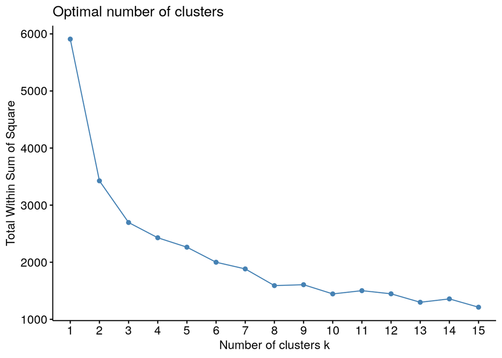

```r
cluster_df_2014_sc <- cluster_df_2014 %>%
  select(-c(BARRIO)) %>%
  scale() %>%
  data.frame(.)

fviz_nbclust(cluster_df_2014_sc, kmeans, method = "wss", k.max = 15)
```

Como se puede evidenciar, entre 3 y 5 clusters, la ganancia marginal en la suma total de cuadrados es poca en función del aumento del número de clusters, por lo que haremos 4 clusters para dicho año.

```r
set.seed(0)
kmeans.2014 <- kmeans(x = cluster_df_2014_sc, centers = 4, iter.max = 200)
cluster_df_2014$cluster <- as.integer(kmeans.2014$cluster)
```

Veamos algunas estadísticas de los clusters

```r
cluster_df_2014 %>%
  select(-c(BARRIO)) %>%
  group_by(cluster) %>%
  summarise_all(funs(mean(.))) %>%
  merge(cluster_df_2014 %>%
          group_by(cluster) %>%
          summarise(numero_barrios=n(), .groups="drop"), by="cluster") %>%
  kable() %>%
  kable_styling(bootstrap_options = c("striped"), position = "left") %>%
  scroll_box(height = "300px")
```

| cluster | promedio_accidente_mes | std_accidentes_mes | AVG_OTRO_ACCIDENTE | AVG_ATROPELLOS | AVG_CAIDA_OCUPANTE | AVG_CHOQUE | AVG_INCENDIO | AVG_VOLCAMIENTOS | AVG_HERIDO | AVG_MUERTO | AVG_SOLO_DANOS | AVG_SIN_DISENO | AVG_CICLO_RUTA | AVG_GLORIETA | AVG_INTERSECCION | AVG_LOTE_PREDIO | AVG_TRAMO_VIDA | AVG_VIA_PEATOLNAL | AVG_DISENO_TUNEL_PUENTE | numero_barrios |
| --- | --- | --- | --- | --- | --- | --- | --- | --- | --- | --- | --- | --- | --- | --- | --- | --- | --- | --- | --- | --- |
| 1 | 9.701734 | 3.177636 | 14.927835 | 15.505155 | 14.237113 | 68.29897 | 0.0721649 | 3.3092784 | 72.07216 | 0.7010309 | 43.57732 | 0.7010309 | 0.5773196 | 0.5567010 | 14.505155 | 3.3402062 | 96.22680 | 0.0206186 | 0.4226804 | 97 |
| 2 | 2.780002 | 1.191549 | 3.260563 | 4.619718 | 3.049296 | 16.90845 | 0.0000000 | 0.6901408 | 17.61972 | 0.1408451 | 10.76761 | 0.1408451 | 0.1408451 | 0.0633803 | 3.338028 | 0.9507042 | 23.87324 | 0.0000000 | 0.0211268 | 142 |
| 3 | 54.219298 | 9.141590 | 54.210526 | 60.421053 | 47.894737 | 475.73684 | 0.0526316 | 12.3157895 | 298.89474 | 4.1578947 | 347.57895 | 4.1578947 | 2.6842105 | 19.4736842 | 69.263158 | 14.9473684 | 529.47368 | 0.0526316 | 10.5789474 | 19 |
| 4 | 21.442901 | 4.913191 | 29.259259 | 27.240741 | 26.537037 | 168.37037 | 0.0000000 | 5.9074074 | 146.38889 | 1.6481481 | 109.27778 | 1.6481481 | 1.2037037 | 4.9814815 | 39.037037 | 6.2962963 | 202.98148 | 0.1481481 | 1.0185185 | 54 |

Es importante llevar el análisis al espacio geográfico para entender las características de ubicación de los barrios con alta accidentalidad dentro de los grupos.

```r
cluster_2014_map <- df %>%
  filter(PERIODO==2014, BARRIO!="") %>%
  group_by(BARRIO) %>%
  summarise(
    lat=mean(LATITUD), lng=mean(LONGITUD), .groups="drop"
  ) %>% merge(cluster_df_2014 %>% select(BARRIO, cluster), by="BARRIO") %>%
  mutate(
    cluster_colors=as.character(ifelse(cluster==3, "red",
                                       ifelse(cluster==4, "orange",
                                              ifelse(cluster==1, "yellow", "green"))))
    )


leaflet(cluster_2014_map) %>% addTiles() %>%
  addCircleMarkers(
    color = ~cluster_colors,
    stroke = FALSE,
    fillOpacity = 0.5,
    lng = ~lng, lat = ~lat,
    label = ~as.character(BARRIO)
  )
```

[interactive chart not shown]

La primera carácteristica que se puede evidenciar de los clusters de los barrios respecto a la ciudad de Medellín, es que aquellos barrios con mayor accidentalidad se encuentran ubicados por las zonas valle y mayormente transitadas en la ciudad, calles como la avenida del río, la avenida guayabal, la avenida de la 33 y sus altededores, y calles como la 30 a la altura de la 80, la 33 con la 65 y la alpujarra entre otros. Mientras que las zonas con menor accidentalidad justamente se encuentran en las periferías de la ciudad, específicamente en el oriente y occidente de la ciudad. Mientras que zonas con el poblado, belen, robledo, se encuentran los niveles de accidentalidad media-alta.

### Clustering año 2015

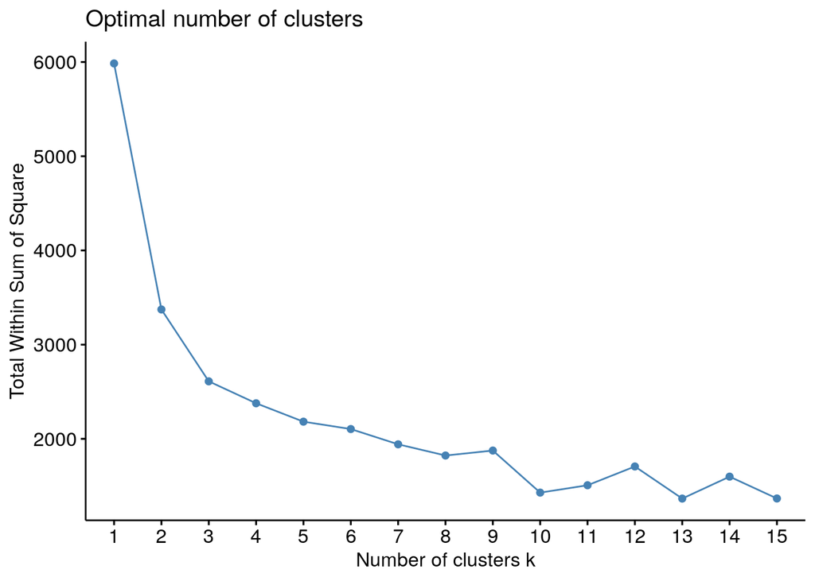

```r
cluster_df_2015 <- cluster_df %>%
  filter(PERIODO==2015) %>%
  select(-c(PERIODO)) %>%
  arrange(promedio_accidente_mes) %>%
  mutate_at(.vars = vars(-BARRIO), .funs = funs(na.constant(.x=., .na = 0)))

cluster_df_2015_sc <- cluster_df_2015 %>%
  select(-c(BARRIO)) %>%
  scale() %>%
  data.frame(.)

fviz_nbclust(cluster_df_2015_sc, kmeans, method = "wss", k.max = 15)
```

```r
set.seed(0)
kmeans.2015 <- kmeans(x = cluster_df_2015_sc, centers = 4, iter.max = 200)
cluster_df_2015$cluster <- as.integer(kmeans.2015$cluster)
```

Veamos algunas estadísticas de los clusters

```r
cluster_df_2015 %>%
  select(-c(BARRIO)) %>%
  group_by(cluster) %>%
  summarise_all(funs(mean(.))) %>%
  merge(cluster_df_2015 %>%
          group_by(cluster) %>%
          summarise(numero_barrios=n(), .groups="drop"), by="cluster") %>%
  kable() %>%
  kable_styling(bootstrap_options = c("striped"), position = "left") %>%
  scroll_box(height = "300px")
```

| cluster | promedio_accidente_mes | std_accidentes_mes | AVG_OTRO_ACCIDENTE | AVG_ATROPELLOS | AVG_CAIDA_OCUPANTE | AVG_CHOQUE | AVG_INCENDIO | AVG_VOLCAMIENTOS | AVG_HERIDO | AVG_MUERTO | AVG_SOLO_DANOS | AVG_SIN_DISENO | AVG_CICLO_RUTA | AVG_GLORIETA | AVG_INTERSECCION | AVG_LOTE_PREDIO | AVG_TRAMO_VIDA | AVG_VIA_PEATOLNAL | AVG_DISENO_TUNEL_PUENTE | numero_barrios |
| --- | --- | --- | --- | --- | --- | --- | --- | --- | --- | --- | --- | --- | --- | --- | --- | --- | --- | --- | --- | --- |
| 1 | 11.762028 | 3.626827 | 16.206186 | 17.639175 | 14.247423 | 87.54639 | 0.0000000 | 5.505155 | 87.72165 | 0.7010309 | 52.72165 | 0.7010309 | 0.2577320 | 0.9175258 | 22.453608 | 4.402062 | 112.13402 | 0.0206186 | 0.2577320 | 97 |
| 2 | 3.238126 | 1.341640 | 3.512048 | 4.656626 | 3.343374 | 21.45783 | 0.0000000 | 1.198795 | 20.18072 | 0.2168675 | 13.77108 | 0.2168675 | 0.0722892 | 0.0903614 | 3.909639 | 1.343373 | 28.40964 | 0.0060241 | 0.1204819 | 166 |
| 3 | 56.986111 | 9.462775 | 55.666667 | 58.888889 | 47.000000 | 503.72222 | 0.0000000 | 18.555556 | 315.11111 | 4.8888889 | 363.83333 | 4.8888889 | 1.5000000 | 20.8333333 | 78.000000 | 15.111111 | 554.94444 | 0.2222222 | 8.3333333 | 18 |
| 4 | 24.780952 | 5.589009 | 30.342857 | 26.885714 | 25.942857 | 203.65714 | 0.0285714 | 10.514286 | 164.05714 | 1.6571429 | 131.65714 | 1.6571429 | 0.8285714 | 7.7714286 | 44.657143 | 8.485714 | 232.77143 | 0.0000000 | 1.2000000 | 35 |

Para el año 2015, vemos que se conserva una estructura muy similar a la clusterización de los barrios por los diferentes niveles de accidentes, se puede dividir entre niveles de **muy alta**, **alta**, **moderada** y **baja** accidentalidad.

```r
cluster_2015_map <- df %>%
  filter(PERIODO==2015, BARRIO!="") %>%
  group_by(BARRIO) %>%
  summarise(
    lat=mean(LATITUD), lng=mean(LONGITUD), .groups="drop"
  ) %>% merge(cluster_df_2015 %>% select(BARRIO, cluster), by="BARRIO") %>%
  mutate(
    cluster_colors=as.character(ifelse(cluster==3, "red",
                                       ifelse(cluster==4, "orange",
                                              ifelse(cluster==1, "yellow", "green"))))
    )


leaflet(cluster_2015_map) %>% addTiles() %>%
  addCircleMarkers(
    color = ~cluster_colors,
    stroke = FALSE,
    fillOpacity = 0.5,
    lng = ~lng, lat = ~lat,
    label = ~as.character(BARRIO)
  )
```

[interactive chart not shown]

### Clustering año 2016

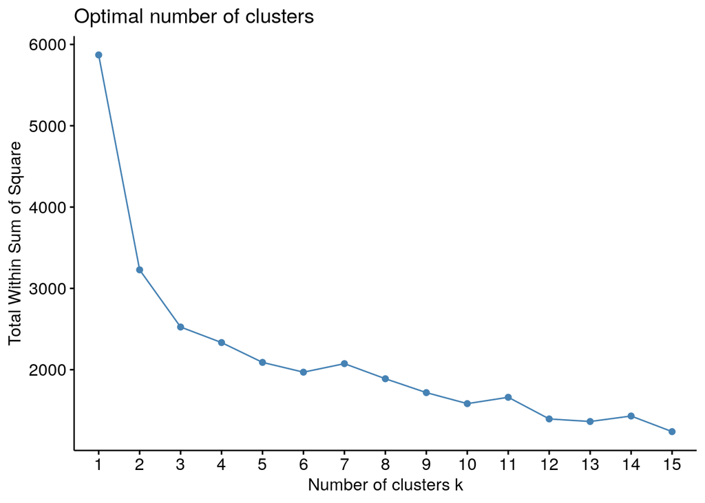

```r
cluster_df_2016 <- cluster_df %>%
  filter(PERIODO==2016) %>%
  select(-c(PERIODO)) %>%
  arrange(promedio_accidente_mes) %>%
  mutate_at(.vars = vars(-BARRIO), .funs = funs(na.constant(.x=., .na = 0)))

cluster_df_2016_sc <- cluster_df_2016 %>%
  select(-c(BARRIO)) %>%
  scale() %>%
  data.frame(.)

fviz_nbclust(cluster_df_2016_sc, kmeans, method = "wss", k.max = 15)
```

Veamos algunas estadísticas de los clusters

```r
set.seed(0)
kmeans.2016 <- kmeans(x = cluster_df_2016_sc, centers = 4, iter.max = 200)
cluster_df_2016$cluster <- as.integer(kmeans.2016$cluster)

cluster_df_2016 %>%
  select(-c(BARRIO)) %>%
  group_by(cluster) %>%
  summarise_all(funs(mean(.))) %>%
  merge(cluster_df_2016 %>%
          group_by(cluster) %>%
          summarise(numero_barrios=n(), .groups="drop"), by="cluster") %>%
  kable() %>%
  kable_styling(bootstrap_options = c("striped"), position = "left") %>%
  scroll_box(height = "300px")
```

| cluster | promedio_accidente_mes | std_accidentes_mes | AVG_OTRO_ACCIDENTE | AVG_ATROPELLOS | AVG_CAIDA_OCUPANTE | AVG_CHOQUE | AVG_INCENDIO | AVG_VOLCAMIENTOS | AVG_HERIDO | AVG_MUERTO | AVG_SOLO_DANOS | AVG_SIN_DISENO | AVG_CICLO_RUTA | AVG_GLORIETA | AVG_INTERSECCION | AVG_LOTE_PREDIO | AVG_TRAMO_VIDA | AVG_VIA_PEATOLNAL | AVG_DISENO_TUNEL_PUENTE | numero_barrios |
| --- | --- | --- | --- | --- | --- | --- | --- | --- | --- | --- | --- | --- | --- | --- | --- | --- | --- | --- | --- | --- |
| 1 | 12.855611 | 3.564796 | 20.099010 | 17.128713 | 15.772277 | 95.22772 | 0.00 | 6.039604 | 96.74257 | 0.8217822 | 56.70297 | 0.8217822 | 0.2673267 | 1.2772277 | 24.376238 | 6.50495 | 120.44554 | 0.049505 | 0.5247525 | 101 |
| 2 | 3.446464 | 1.501098 | 4.469512 | 5.182927 | 3.987805 | 22.21341 | 0.00 | 1.518293 | 23.14024 | 0.2012195 | 14.03049 | 0.2012195 | 0.0792683 | 0.0853659 | 4.713415 | 1.72561 | 30.46951 | 0.000000 | 0.0975610 | 164 |
| 3 | 54.562500 | 8.356290 | 62.400000 | 51.000000 | 41.500000 | 481.80000 | 0.05 | 18.000000 | 309.95000 | 4.0500000 | 340.75000 | 4.0500000 | 1.3500000 | 25.0500000 | 85.850000 | 20.85000 | 506.95000 | 0.350000 | 10.3000000 | 20 |
| 4 | 26.786667 | 5.587381 | 34.560000 | 22.680000 | 24.120000 | 229.36000 | 0.12 | 10.600000 | 169.16000 | 1.5200000 | 150.76000 | 1.5200000 | 1.0400000 | 10.2800000 | 47.880000 | 9.52000 | 247.64000 | 0.280000 | 3.2800000 | 25 |

```r
cluster_2016_map <- df %>%
  filter(PERIODO==2016, BARRIO!="") %>%
  group_by(BARRIO) %>%
  summarise(
    lat=mean(LATITUD), lng=mean(LONGITUD), .groups="drop"
  ) %>% merge(cluster_df_2016 %>% select(BARRIO, cluster), by="BARRIO") %>%
  mutate(
    cluster_colors=as.character(ifelse(cluster==3, "red",
                                       ifelse(cluster==4, "orange",
                                              ifelse(cluster==1, "yellow", "green"))))
    )


leaflet(cluster_2016_map) %>% addTiles() %>%
  addCircleMarkers(
    color = ~cluster_colors,
    stroke = FALSE,
    fillOpacity = 0.5,
    lng = ~lng, lat = ~lat,
    label = ~as.character(BARRIO)
  )
```

[interactive chart not shown]

### Clustering año 2017

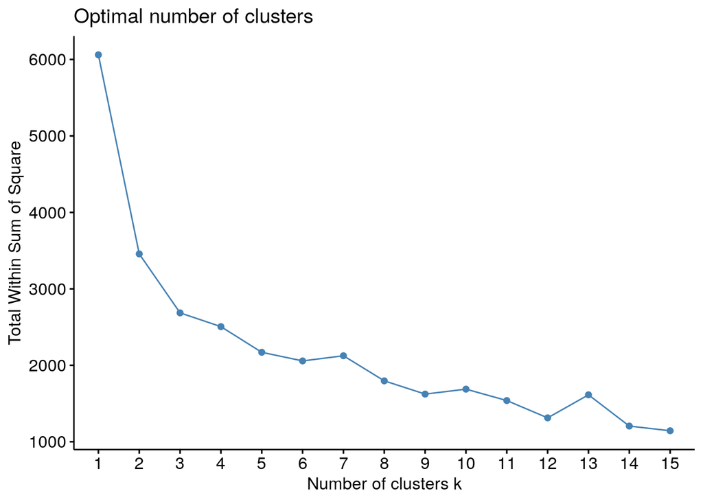

```r
cluster_df_2017 <- cluster_df %>%
  filter(PERIODO==2017) %>%
  select(-c(PERIODO)) %>%
  arrange(promedio_accidente_mes) %>%
  mutate_at(.vars = vars(-BARRIO), .funs = funs(na.constant(.x=., .na = 0)))

cluster_df_2017_sc <- cluster_df_2017 %>%
  select(-c(BARRIO)) %>%
  scale() %>%
  data.frame(.)

fviz_nbclust(cluster_df_2017_sc, kmeans, method = "wss", k.max = 15)
```

Veamos algunas estadísticas de los clusters

```r
set.seed(0)
kmeans.2017 <- kmeans(x = cluster_df_2017_sc, centers = 3, iter.max = 200)
cluster_df_2017$cluster <- as.integer(kmeans.2017$cluster)

cluster_df_2017 %>%
  select(-c(BARRIO)) %>%
  group_by(cluster) %>%
  summarise_all(funs(mean(.))) %>%
  merge(cluster_df_2017 %>%
          group_by(cluster) %>%
          summarise(numero_barrios=n(), .groups="drop"), by="cluster") %>%
  kable() %>%
  kable_styling(bootstrap_options = c("striped"), position = "left") %>%
  scroll_box(height = "300px")
```

| cluster | promedio_accidente_mes | std_accidentes_mes | AVG_OTRO_ACCIDENTE | AVG_ATROPELLOS | AVG_CAIDA_OCUPANTE | AVG_CHOQUE | AVG_INCENDIO | AVG_VOLCAMIENTOS | AVG_HERIDO | AVG_MUERTO | AVG_SOLO_DANOS | AVG_SIN_DISENO | AVG_CICLO_RUTA | AVG_GLORIETA | AVG_INTERSECCION | AVG_LOTE_PREDIO | AVG_TRAMO_VIDA | AVG_VIA_PEATOLNAL | AVG_DISENO_TUNEL_PUENTE | numero_barrios |
| --- | --- | --- | --- | --- | --- | --- | --- | --- | --- | --- | --- | --- | --- | --- | --- | --- | --- | --- | --- | --- |
| 1 | 17.693841 | 4.596793 | 24.282609 | 16.521739 | 18.673913 | 144.96739 | 0.0217391 | 7.858696 | 117.50000 | 0.7065217 | 94.11957 | 0.7065217 | 0.9891304 | 5.663043 | 46.14130 | 24.043478 | 132.53261 | 0.0217391 | 2.2282609 | 92 |
| 2 | 4.073018 | 1.657475 | 5.407767 | 5.514563 | 3.941748 | 27.79126 | 0.0000000 | 1.805825 | 26.04369 | 0.3543689 | 18.06311 | 0.3543689 | 0.1553398 | 0.461165 | 8.61165 | 6.412621 | 28.21845 | 0.0048544 | 0.2427184 | 206 |
| 3 | 52.541667 | 9.121845 | 62.272727 | 44.727273 | 41.045454 | 460.68182 | 0.0909091 | 21.681818 | 304.09091 | 4.0909091 | 322.31818 | 4.0909091 | 3.1818182 | 34.090909 | 101.31818 | 54.318182 | 412.77273 | 0.1363636 | 20.5909091 | 22 |

Para el año 2017 se intentó realizar la clusterización con `k = 4`, sin embargo, agrupo no más de 5 barrios para la accidentalidad más baja y la diferencia en las estadísticas eran mínimas, por lo que hizó más sentido hacer el agrupamiento para un parámetro de `k = 3`.

```r
cluster_2017_map <- df %>%
  filter(PERIODO==2017, BARRIO!="") %>%
  group_by(BARRIO) %>%
  summarise(
    lat=mean(LATITUD), lng=mean(LONGITUD), .groups="drop"
  ) %>% merge(cluster_df_2017 %>% select(BARRIO, cluster), by="BARRIO") %>%
  mutate(
    cluster_colors=as.character(
      ifelse(
        cluster==3, "red",
        ifelse(cluster==1, "orange",
               "green")
      )
    )
  )


leaflet(cluster_2017_map) %>% addTiles() %>%
  addCircleMarkers(
    color = ~cluster_colors,
    stroke = FALSE,
    fillOpacity = 0.5,
    lng = ~lng, lat = ~lat,
    label = ~as.character(BARRIO)
  )
```

[interactive chart not shown]

### Clustering año 2018

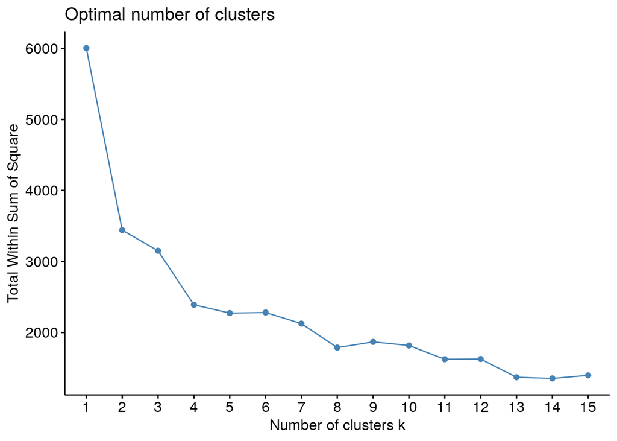

```r
cluster_df_2018 <- cluster_df %>%
  filter(PERIODO==2018) %>%
  select(-c(PERIODO)) %>%
  arrange(promedio_accidente_mes) %>%
  mutate_at(.vars = vars(-BARRIO), .funs = funs(na.constant(.x=., .na = 0)))

cluster_df_2018_sc <- cluster_df_2018 %>%
  select(-c(BARRIO)) %>%
  scale() %>%
  data.frame(.)

fviz_nbclust(cluster_df_2018_sc, kmeans, method = "wss", k.max = 15)
```

Veamos algunas estadísticas de los clusters

```r
set.seed(0)
kmeans.2018 <- kmeans(x = cluster_df_2018_sc, centers = 4, iter.max = 200)
cluster_df_2018$cluster <- as.integer(kmeans.2018$cluster)

cluster_df_2018 %>%
  select(-c(BARRIO)) %>%
  group_by(cluster) %>%
  summarise_all(funs(mean(.))) %>%
  merge(cluster_df_2018 %>%
          group_by(cluster) %>%
          summarise(numero_barrios=n(), .groups="drop"), by="cluster") %>%
  kable() %>%
  kable_styling(bootstrap_options = c("striped"), position = "left") %>%
  scroll_box(height = "300px")
```

| cluster | promedio_accidente_mes | std_accidentes_mes | AVG_OTRO_ACCIDENTE | AVG_ATROPELLOS | AVG_CAIDA_OCUPANTE | AVG_CHOQUE | AVG_INCENDIO | AVG_VOLCAMIENTOS | AVG_HERIDO | AVG_MUERTO | AVG_SOLO_DANOS | AVG_SIN_DISENO | AVG_CICLO_RUTA | AVG_GLORIETA | AVG_INTERSECCION | AVG_LOTE_PREDIO | AVG_TRAMO_VIDA | AVG_VIA_PEATOLNAL | AVG_DISENO_TUNEL_PUENTE | numero_barrios |
| --- | --- | --- | --- | --- | --- | --- | --- | --- | --- | --- | --- | --- | --- | --- | --- | --- | --- | --- | --- | --- |
| 1 | 14.479854 | 3.998100 | 18.054945 | 16.901099 | 19.186813 | 113.96703 | 0.0109890 | 5.637363 | 100.79121 | 1.4175824 | 71.54945 | 1.0219780 | 0.5494505 | 2.8461538 | 37.747253 | 30.000000 | 100.28571 | 0.0219780 | 1.2857143 | 91 |
| 2 | 3.707659 | 1.499981 | 4.314433 | 4.603093 | 4.247423 | 26.21649 | 0.0051546 | 1.216495 | 22.71649 | 0.2628866 | 17.62371 | 0.2164948 | 0.0979381 | 0.3556701 | 7.520619 | 7.402062 | 24.81443 | 0.0000000 | 0.1958763 | 194 |
| 3 | 57.597222 | 8.792773 | 57.666667 | 53.666667 | 47.583333 | 512.75000 | 0.4166667 | 19.083333 | 327.66667 | 5.2500000 | 358.25000 | 3.8333333 | 2.4166667 | 25.2500000 | 120.416667 | 74.833333 | 444.83333 | 0.1666667 | 19.4166667 | 12 |
| 4 | 34.916667 | 7.156753 | 28.350000 | 26.750000 | 23.800000 | 330.30000 | 0.0000000 | 9.800000 | 174.00000 | 2.8500000 | 242.15000 | 2.0500000 | 1.8000000 | 33.5500000 | 78.600000 | 43.100000 | 243.15000 | 0.0500000 | 16.7000000 | 20 |

Para el año 2018, se mantuvo la estructura de 4 clusters con diferencias importantes entre las estadísticas de accidentes.

```r
cluster_2018_map <- df %>%
  filter(PERIODO==2018, BARRIO!="") %>%
  group_by(BARRIO) %>%
  summarise(
    lat=mean(LATITUD), lng=mean(LONGITUD), .groups="drop"
  ) %>% merge(cluster_df_2018 %>% select(BARRIO, cluster), by="BARRIO") %>%
  mutate(
    cluster_colors=as.character(
      ifelse(
        cluster==3, "red",
        ifelse(
          cluster==4, "orange",
          ifelse(
            cluster==1, "yellow",
            "green"
          )
        )
      )
    )
  )


leaflet(cluster_2018_map) %>% addTiles() %>%
  addCircleMarkers(
    color = ~cluster_colors,
    stroke = FALSE,
    fillOpacity = 0.5,
    lng = ~lng, lat = ~lat,
    label = ~as.character(BARRIO)
  )
```

[interactive chart not shown]